# Homerwork Week 5 Day 1

Sandra Tobon

06/04/2020

# 1 MVP

A1. The columns backpack_weight, body_weight, that usually are double here are integer so we can try them as cardinal values. back_problems only have 0 and 1 so we could change it to logical value. All the character variables are factors.

```r
names(backpack)
```

```
## [1] "backpack_weight" "body_weight"     "ratio"           "back_problems"
## [5] "major"           "year"            "sex"             "status"
## [9] "units"
```

```r
dim(backpack)
```

```
## [1] 100   9
```

```r
backpack <- backpack
```

2. What is the distribution of backpack weights that students are carrying? Choose an appropriate graph to show the distribution.

A2. Normally weight must be analyzed as continues but here the data is integer, so we could analyzed them as cardinal without do any transformation. We will use bar char in this case.  
The graph shows that a big part of the students carry bacpacks with weights between 5 to 15. Only one student has a backpack that is heavier than 30.

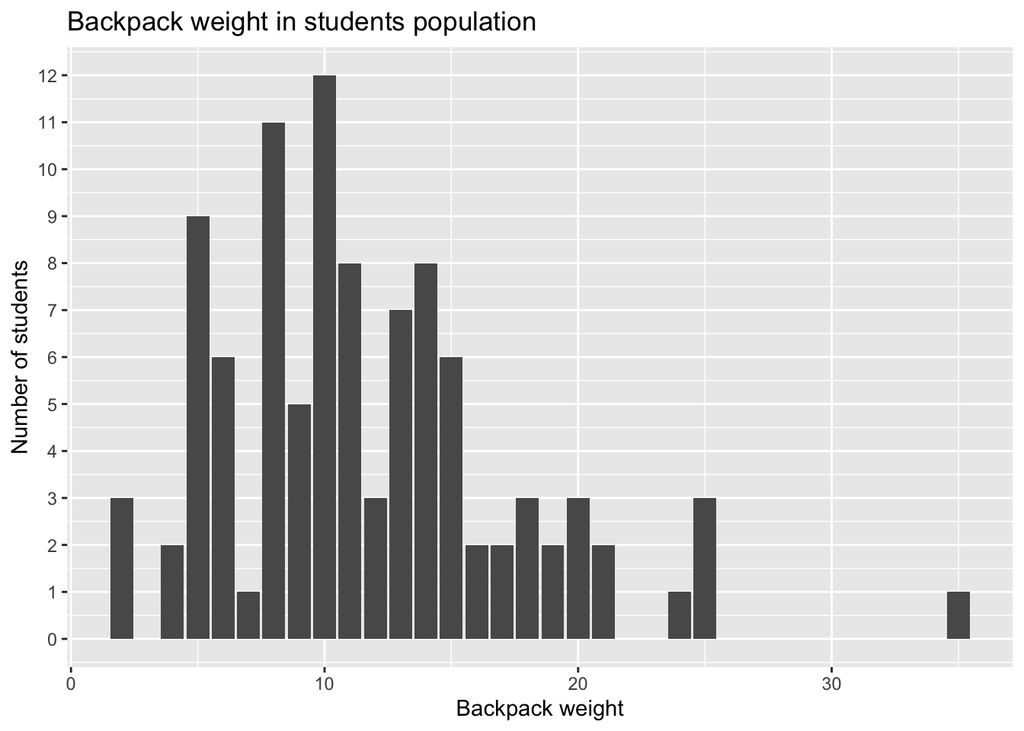

```r
backpack %>%
  ggplot() +
  aes(x = backpack_weight) +
  geom_bar() +
  scale_y_continuous(breaks = 0:13) +
  labs(
    x = "Backpack weight",
    y = "Number of students",
    title = "Backpack weight in students population"
  )
```

3. Are there differences in backpack weight between sex?

A3. The backpack weight most commonly carried by females is 10 pounds and by males is 11 pounds. The women use to carry a little less weight than men.

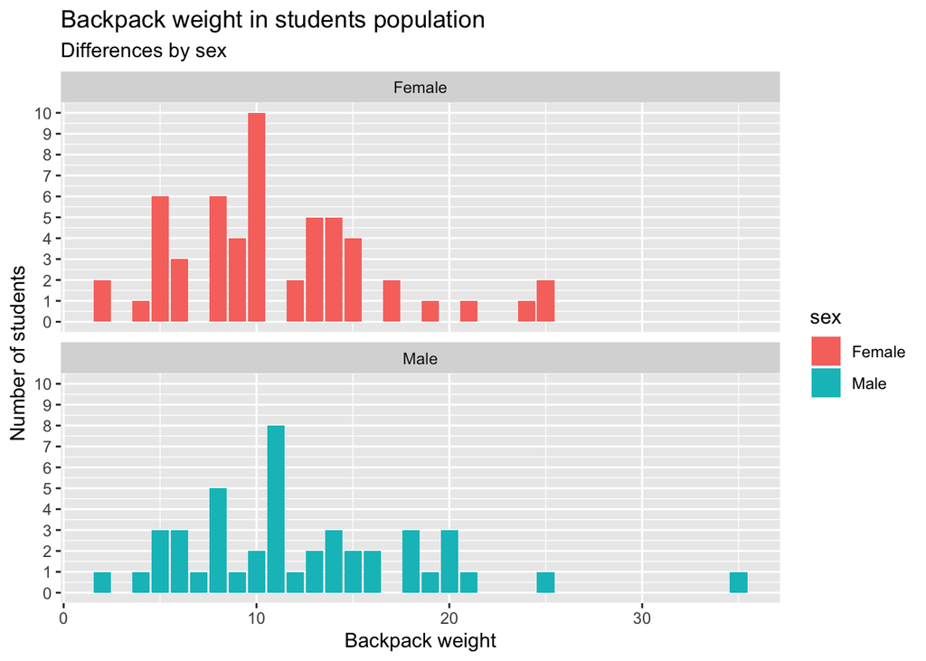

```r
backpack %>%
  ggplot() +
  aes(x = backpack_weight, fill = sex) +
  geom_bar() +
  scale_y_continuous(breaks = 0:13) +
  labs(
    x = "Backpack weight",
    y = "Number of students",
    title = "Backpack weight in students population",
    subtitle = "Differences by sex"
  ) +
  facet_wrap(~sex, nrow = 2)
```

4. What is the relationship between body weight and backpack weight?

A4. The weight of the backpack isn’t directly conecty with the weight of the students, because even when the student that carries the heaviest bagpack has a body weight above the mean the other students with a body weight above the mean carries backpacks that are close to the mean of the backpacks weights.

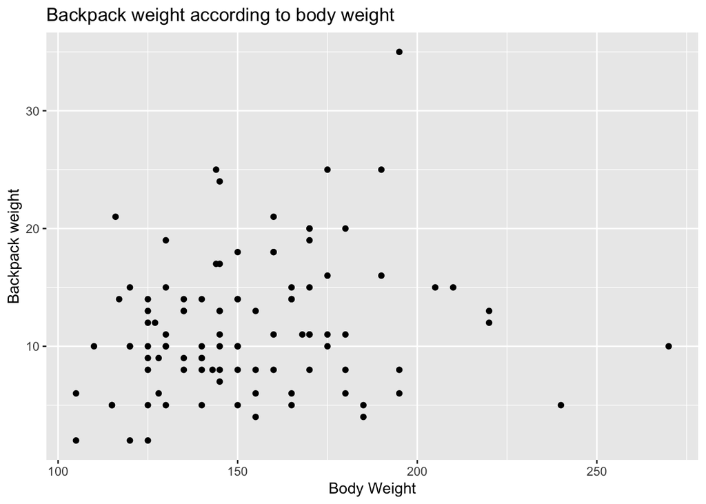

```r
backpack %>%
  ggplot() +
  aes(x = body_weight, y = backpack_weight) +
  geom_point()  +
  labs(
    x = "Body Weight",
    y = "Backpack weight",
    title = "Backpack weight according to body weight"
  )
```

5. Is this relationship different between men and women? Choose an appropriate plot and interpret your findings?

A5. Most of the women are less heavy than men. When the women are havier than the mean they didn’t carry hevier backpack.

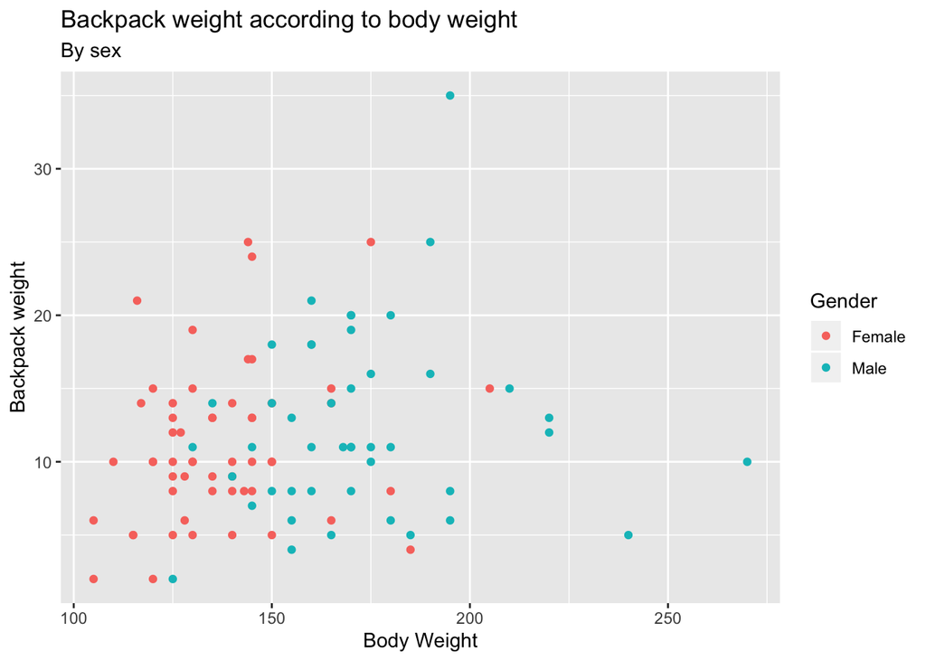

```r
backpack %>%
  ggplot() +
  aes(x = body_weight, y = backpack_weight, colour = sex) +
  geom_point()  +
  labs(
    x = "Body Weight",
    y = "Backpack weight",
    title = "Backpack weight according to body weight",
    subtitle = "By sex",
    colour = "Gender"
  )
```

6. What proportion of students report back pain?

A6. The proportion of the students with back pain is around 1/3 of the students population.

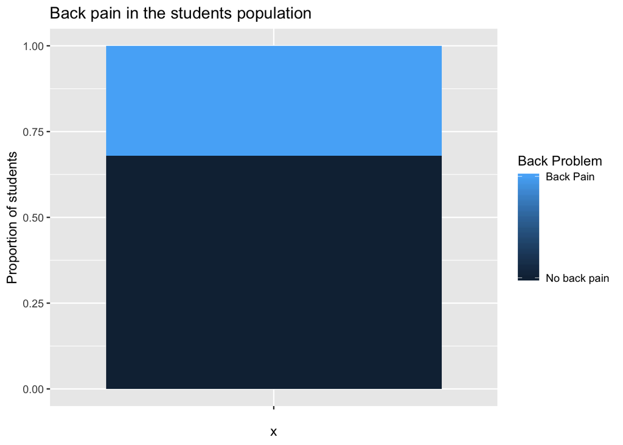

```r
backpack %>%
  group_by(back_problems) %>%
  summarise(percent_back_problems = n()/100) %>%
  ggplot() +
  aes(x = "", y= percent_back_problems, fill = back_problems) +
  geom_bar(stat = "identity") +
  scale_fill_continuous(breaks = c(0, 1), labels = c("0" = "No back pain", "1" = "Back Pain")) +
  labs(
    y = "Proportion of students",
    title = "Back pain in the students population",
    fill = "Back Problem"
  )
```

7. Is this proportion different between men and women?

A7. Yes, actually more women report back pain than men.

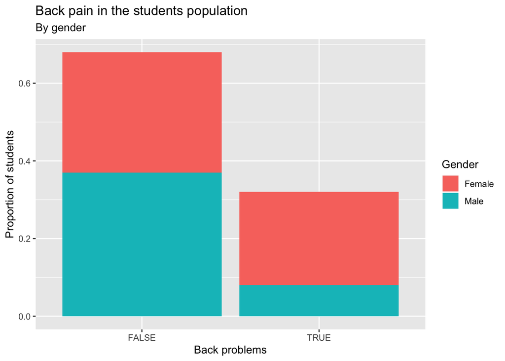

```r
backpack %>%
  mutate_at("back_problems", as.logical) %>%
  group_by(back_problems, sex) %>%
  summarise(percent_back_problems = n()/100) %>%
  ggplot() +
  aes(x = back_problems, y= percent_back_problems, fill = sex) +
  geom_bar(stat = "identity") +
  labs(
    x = "Back problems",
    y = "Proportion of students",
    title = "Back pain in the students population",
    subtitle = "By gender",
    fill = "Gender"
  )
```

8. Describe the relationship between backpack weight, body weight, gender and reported backpain.

A8. The distribution in women with and without back pain is quite same special in the amount of weight that they carried, but are more women with weight above 150 that feel back pain than those than don’t feel back pain.  
The distribution in men with and without back pain is really different. The men with back pain have body weight between 150 to 200 and they carry between 5 to 20. The men without back pain are more disperse.

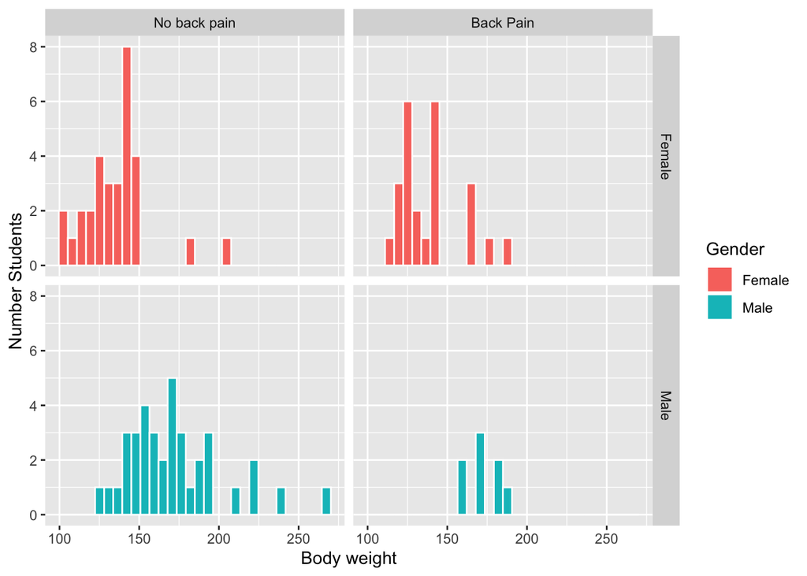

```r
backpack %>%
  ggplot() +
  aes(x = body_weight, fill = sex) +
  geom_histogram(colour = "white") +
  facet_grid(sex ~ back_problems,
             labeller = labeller(back_problems =c("0" = "No back pain", "1" = "Back Pain"))) +
  labs(
    x = "Body weight",
    y = "Number Students",
    fill = "Gender"
  )
```

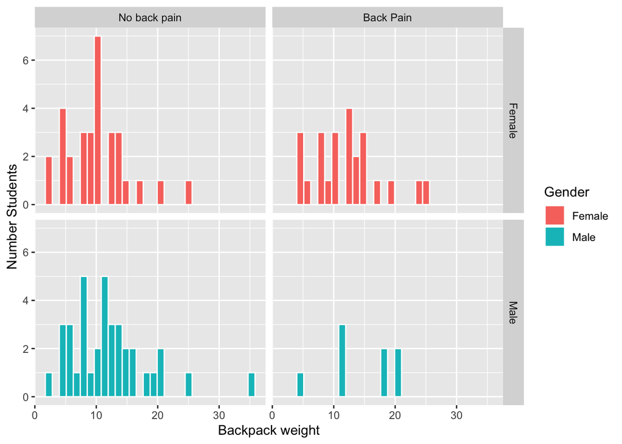

```r
backpack %>%
  ggplot() +
  aes(x = backpack_weight, fill = sex) +
  geom_histogram(colour = "white") +
  facet_grid(sex ~ back_problems,
             labeller = labeller(back_problems =c("0" = "No back pain", "1" = "Back Pain"))) +
  labs(
    x = "Backpack weight",
    y = "Number Students",
    fill = "Gender"
  )
```

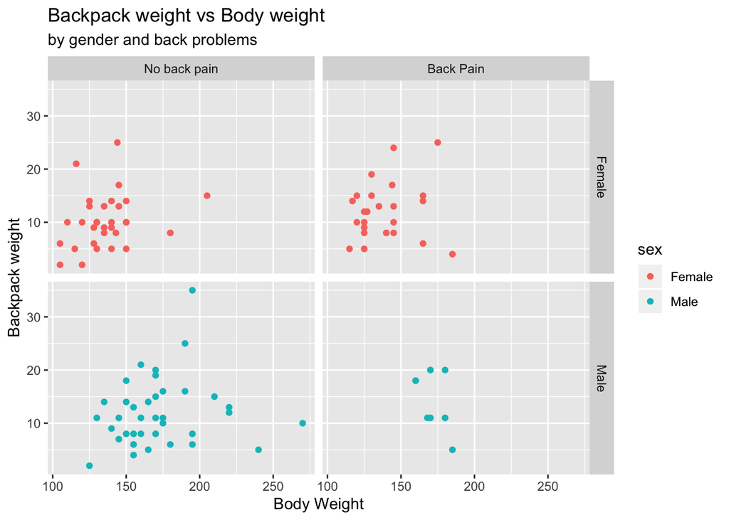

```r
backpack %>%
  ggplot() +
  aes(body_weight, backpack_weight, colour = sex) +
  geom_point() +
  facet_grid(sex ~ back_problems,
             labeller = labeller(back_problems =c("0" = "No back pain", "1" = "Back Pain"))) +
  labs(
    x = "Body Weight",
    y = "Backpack weight",
    title = "Backpack weight vs Body weight",
    subtitle = "by gender and back problems",
    fill = "Gender"
  )
```

# 2 EXTENSIONS

1. Does reported backpain differ across the year groups? Ignore year 0 in your data?

A1. Most of the students with back pain are in the group of 3 years but also this group is the one with the majority of the population.

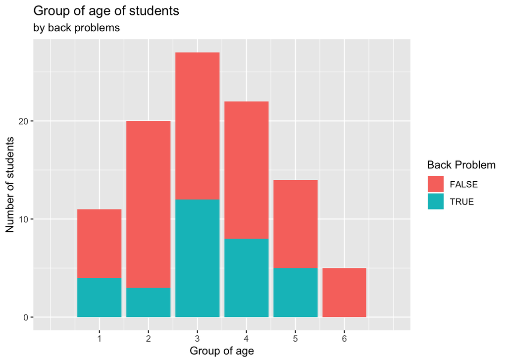

```r
backpack %>%
  mutate_at("back_problems", as.logical) %>%
  ggplot() +
  aes(x = year, fill = back_problems) +
  geom_bar() +
  scale_x_continuous(breaks = c(1:6), limits = c(0,7)) +
  labs(
    x = "Group of age",
    y = "Number of students",
    title = "Group of age of students",
    subtitle = "by back problems",
    fill = "Back Problem"
  )
```

2. Is there a difference between how heavy the bags those in different years carry?

A2. In the year 0 the weight of the backpack is low but it isn’t the lowest. The person with thw heavier backpack is in the group of 5 years. In the group of people between 2 to 5 years some students have backpacks heavier than 20. The lowest backpack weights are in the group of students between 5 to 6 years.

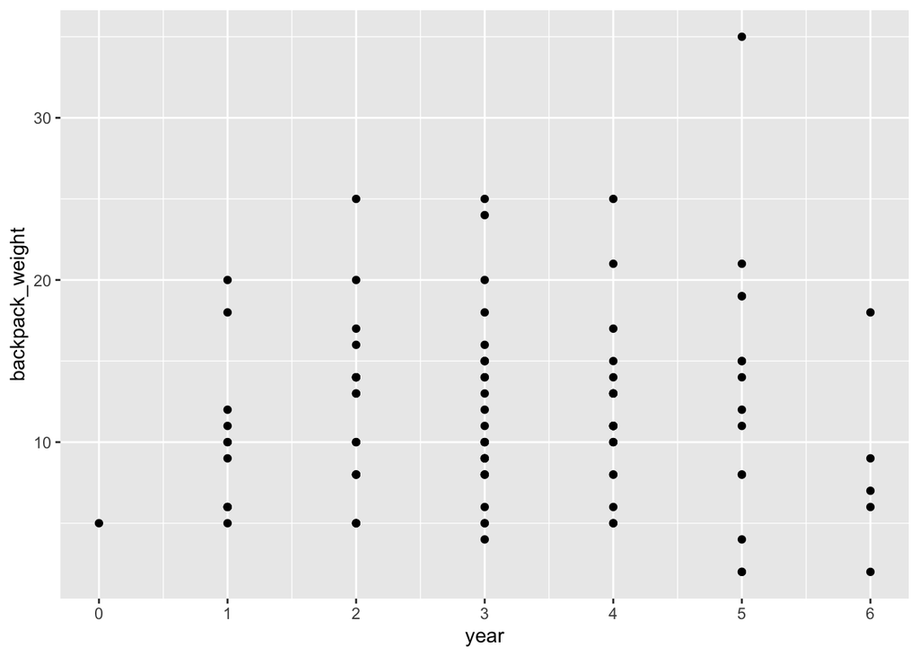

```r
backpack %>%
  ggplot() +
  aes(x = year, y = backpack_weight) +
  geom_point() +
  scale_x_continuous(breaks = c(0:7))
```